If you have decided to complete the previous homework, you do not need to do this one.

If you decide to do this homework, make a copy of this notebook into your own GoogleDrive, and proceed.

# 1. Previous steps before the exercises

# 1 The Data

## 1.1 The MAP for this homework:

I am loading a map found originally [here](https://gist.github.com/sdwfrost/d1c73f91dd9d175998ed166eb216994a) with polygons representing USA counties.

```python
# building the link to GutHub
mainFolderGit="https://github.com/DACSS-CSSmeths/Spatial-Analytics/raw/refs/heads/main/"
fileMapGit='map/counties.geojson'
linkToGitHubMap=mainFolderGit+fileMapGit

## reading the data in using GeoPandas:
# Added a comment
import geopandas as gpd

countiesMap = gpd.read_file(linkToGitHubMap)
countiesMap.info()
```

```
<class 'geopandas.geodataframe.GeoDataFrame'>
RangeIndex: 3220 entries, 0 to 3219
Data columns (total 10 columns):
 #   Column    Non-Null Count  Dtype
---  ------    --------------  -----
 0   STATEFP   3220 non-null   object
 1   COUNTYFP  3220 non-null   object
 2   COUNTYNS  3220 non-null   object
 3   AFFGEOID  3220 non-null   object
 4   GEOID     3220 non-null   object
 5   NAME      3220 non-null   object
 6   LSAD      3220 non-null   object
 7   ALAND     3220 non-null   int64
 8   AWATER    3220 non-null   int64
 9   geometry  3220 non-null   geometry
dtypes: geometry(1), int64(2), object(7)
memory usage: 251.7+ KB
```

```python
# building the link to GutHub
mainFolderGit="https://github.com/DACSS-CSSmeths/Spatial-Analytics/raw/refs/heads/main/"
fileMapGit='map/counties.geojson'
linkToGitHubMap=mainFolderGit+fileMapGit

## reading the data in using GeoPandas:
import geopandas as gpd

countiesMap = gpd.read_file(linkToGitHubMap)
countiesMap.info()
```

```
<class 'geopandas.geodataframe.GeoDataFrame'>
RangeIndex: 3220 entries, 0 to 3219
Data columns (total 10 columns):
 #   Column    Non-Null Count  Dtype
---  ------    --------------  -----
 0   STATEFP   3220 non-null   object
 1   COUNTYFP  3220 non-null   object
 2   COUNTYNS  3220 non-null   object
 3   AFFGEOID  3220 non-null   object
 4   GEOID     3220 non-null   object
 5   NAME      3220 non-null   object
 6   LSAD      3220 non-null   object
 7   ALAND     3220 non-null   int64
 8   AWATER    3220 non-null   int64
 9   geometry  3220 non-null   geometry
dtypes: geometry(1), int64(2), object(7)
memory usage: 251.7+ KB
```

This is only geographic information:

```python
countiesMap.head()
```

|  | STATEFP | COUNTYFP | COUNTYNS | AFFGEOID | GEOID | NAME | LSAD | ALAND | AWATER | geometry |
| --- | --- | --- | --- | --- | --- | --- | --- | --- | --- | --- |
| 0 | 06 | 075 | 00277302 | 0500000US06075 | 06075 | San Francisco | 06 | 121485107 | 479107241 | POLYGON ((-122.51198 37.77113, -122.4654 37.80... |
| 1 | 25 | 025 | 00606939 | 0500000US25025 | 25025 | Suffolk | 06 | 150855462 | 160479920 | POLYGON ((-71.19116 42.28306, -71.15689 42.330... |
| 2 | 31 | 007 | 00835826 | 0500000US31007 | 31007 | Banner | 06 | 1932676697 | 397069 | POLYGON ((-104.05283 41.69795, -103.37039 41.6... |
| 3 | 37 | 181 | 01008591 | 0500000US37181 | 37181 | Vance | 06 | 653705784 | 42187365 | POLYGON ((-78.49778 36.51448, -78.45728 36.541... |
| 4 | 48 | 421 | 01383996 | 0500000US48421 | 48421 | Sherman | 06 | 2390651189 | 428754 | POLYGON ((-102.16246 36.50033, -102.03234 36.5... |

## 1.2 The DATA TABLE for this homework (excel):

This file is originally from this [website](https://www.openintro.org/data/index.php?data=county), I saved it to GitHub:

```python
fileDataGit='data/county.xlsx'
linkToGitHubData=mainFolderGit+fileDataGit

import pandas as pd
countiesData = pd.read_excel(linkToGitHubData,converters={'COUNTYNS':str,'GEOID':str})
countiesData.info()
```

```
<class 'pandas.core.frame.DataFrame'>
RangeIndex: 3142 entries, 0 to 3141
Data columns (total 17 columns):
 #   Column             Non-Null Count  Dtype
---  ------             --------------  -----
 0   name               3142 non-null   object
 1   state              3142 non-null   object
 2   COUNTYNS           3142 non-null   object
 3   GEOID              3142 non-null   object
 4   pop2000            3139 non-null   float64
 5   pop2010            3142 non-null   int64
 6   pop2017            3139 non-null   float64
 7   pop_change         3139 non-null   float64
 8   poverty            3140 non-null   float64
 9   homeownership      3142 non-null   float64
 10  multi_unit         3142 non-null   float64
 11  unemployment_rate  3139 non-null   float64
 12  metro              3139 non-null   object
 13  median_edu         3140 non-null   object
 14  per_capita_income  3140 non-null   float64
 15  median_hh_income   3140 non-null   float64
 16  smoking_ban        2562 non-null   object
dtypes: float64(9), int64(1), object(7)
memory usage: 417.4+ KB
```

Here you have several interesting variables per county:

```python
# you can visit the original website for details
countiesData.head()
```

|  | name | state | COUNTYNS | GEOID | pop2000 | pop2010 | pop2017 | pop_change | poverty | homeownership | multi_unit | unemployment_rate | metro | median_edu | per_capita_income | median_hh_income | smoking_ban |
| --- | --- | --- | --- | --- | --- | --- | --- | --- | --- | --- | --- | --- | --- | --- | --- | --- | --- |
| 0 | Autauga County | Alabama | 00161526 | 01001 | 43671.0 | 54571 | 55504.0 | 1.48 | 13.7 | 77.5 | 7.2 | 3.86 | yes | some_college | 27841.70 | 55317.0 | none |
| 1 | Baldwin County | Alabama | 00161527 | 01003 | 140415.0 | 182265 | 212628.0 | 9.19 | 11.8 | 76.7 | 22.6 | 3.99 | yes | some_college | 27779.85 | 52562.0 | none |
| 2 | Barbour County | Alabama | 00161528 | 01005 | 29038.0 | 27457 | 25270.0 | -6.22 | 27.2 | 68.0 | 11.1 | 5.90 | no | hs_diploma | 17891.73 | 33368.0 | partial |
| 3 | Bibb County | Alabama | 00161529 | 01007 | 20826.0 | 22915 | 22668.0 | 0.73 | 15.2 | 82.9 | 6.6 | 4.39 | yes | hs_diploma | 20572.05 | 43404.0 | none |
| 4 | Blount County | Alabama | 00161530 | 01009 | 51024.0 | 57322 | 58013.0 | 0.68 | 15.6 | 82.0 | 3.7 | 4.02 | yes | hs_diploma | 21367.39 | 47412.0 | none |

# 2 Merging MAP and DATA TABLE

Notice we have two commmon columns that uniquely identify the counties. Let's use them as composite keys:

```python
countiesMapData=countiesMap.merge(countiesData, on=['COUNTYNS','GEOID'])
countiesMapData.info()
```

```
<class 'geopandas.geodataframe.GeoDataFrame'>
RangeIndex: 3142 entries, 0 to 3141
Data columns (total 25 columns):
 #   Column             Non-Null Count  Dtype
---  ------             --------------  -----
 0   STATEFP            3142 non-null   object
 1   COUNTYFP           3142 non-null   object
 2   COUNTYNS           3142 non-null   object
 3   AFFGEOID           3142 non-null   object
 4   GEOID              3142 non-null   object
 5   NAME               3142 non-null   object
 6   LSAD               3142 non-null   object
 7   ALAND              3142 non-null   int64
 8   AWATER             3142 non-null   int64
 9   geometry           3142 non-null   geometry
```

[output cut: 17 more lines]

# 3 The DATA that we need

Fir this homework, you will analyze the counties in the New England area:

```python
# columns of interest
# NAME is county name
countiesMapData.loc[:,['NAME','state']]
```

|  | NAME | state |
| --- | --- | --- |
| 0 | San Francisco | California |
| 1 | Suffolk | Massachusetts |
| 2 | Banner | Nebraska |
| 3 | Vance | North Carolina |
| 4 | Sherman | Texas |
| ... | ... | ... |
| 3137 | Douglas | Nevada |
| 3138 | Pike | Missouri |
| 3139 | Hamilton | Iowa |
| 3140 | Carroll | Iowa |
| 3141 | Columbia | Georgia |

3142 rows × 2 columns

Then, we need to keep only the counties in that area:

```python
# list of NewEngland states
NEng_list=['Connecticut', 'Maine', 'Massachusetts', 'New Hampshire', 'Rhode Island']

# keeping rows (counties) in New England
countiesMapData_NEng=countiesMapData[countiesMapData.state.isin(NEng_list)]

# resetting the row index
countiesMapData_NEng.reset_index(inplace=True)

# county count
countiesMapData_NEng.state.value_counts()
```

```
state
Maine            16
Massachusetts    14
New Hampshire    10
Connecticut       8
Rhode Island      5
Name: count, dtype: int64
```

These are the counties:

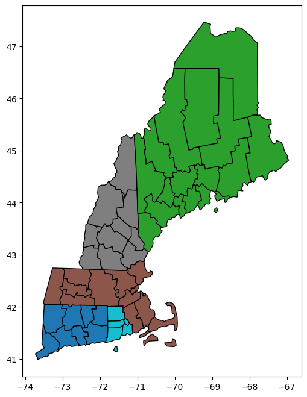

```python
countiesMapData_NEng.plot(column='state',edgecolor='black',figsize=(8,8))
```

Please install this before proceeding to exercises:

```python
# !pip install folium pysal
```

# 4 Exercises

1. Does the distribution of the variable '*unemployment_rate*' in New England States is affected by the proximity of the closest six counties?

**Change the code below to get the answer**:

*copy this code and paste it in another cell where you make the changes needed*

```
from libpysal.weights import KNN

w_knn8 = KNN.from_dataframe(peru_hdi_map, k=8)

w_queen.transform = 'R'

moranHDI = Moran(y=peru_hdi_map['hdi'],
                 w=w_knn8)

# results
moranHDI.I, moranHDI.p_sim
```

```python
from libpysal.weights import KNN
from esda.moran import Moran

#create matrix using KNN with k=6
w_knn6 = KNN.from_dataframe(countiesMapData_NEng, k=6)
w_knn6.transform = 'R'

#compute and print Moran's I for unemployment rate
moranUnemployment = Moran(countiesMapData_NEng['unemployment_rate'], w_knn6)
print("Moran's I:", moranUnemployment.I, "p-value:", moranUnemployment.p_sim)
```

```
Moran's I: 0.6272388089949718 p-value: 0.001
```

2. If you find that the relationship is significant, compute the columns with the quadrants.

**Change this code to achieve that**:

```
#libraries needed (from pysal)
from esda.moran import Moran_Local

#you get LISA for HDI
lisa_HDI = Moran_Local(y=peru_hdi_map['hdi'],
                       w=w_knn8,
                       seed=2022)
#ResultLISA holds the results
ResultLISA=pd.DataFrame({'lisa_Qlabel':lisa_HDI.q, 'lisa_Qsig':lisa_HDI.p_sim})

#you recode the quadrant to label the non-significant cases.
peru_hdi_map.loc[:,'HDI_quadrant']=[q if p <0.05 else 0 for q,p in zip(ResultLISA.lisa_Qlabel,ResultLISA.lisa_Qsig)  ]

# labels are currently numbers 0-4, now rename with text

newLabels = {0: '0_NoSig',1: '1_HotSpot',2: '2_ColdOutlier',3: '3_ColdSpot',4: '4_HotOutlier'}
peru_hdi_map.replace({'HDI_quadrant':newLabels},inplace=True)
```

```python
from esda.moran import Moran_Local

if moranUnemployment.p_sim < 0.05:
    #calculate and store LISA statistics
    lisa_unemployment = Moran_Local(countiesMapData_NEng['unemployment_rate'], w_knn6, seed=2022)
    ResultLISA = pd.DataFrame({'lisa_Qlabel': lisa_unemployment.q, 'lisa_Qsig': lisa_unemployment.p_sim})

    #label each quadrant
    unemployment_quadrant = []
    i = 0
    while i < len(ResultLISA):
        if ResultLISA.lisa_Qsig[i] < 0.05:
            unemployment_quadrant.append(ResultLISA.lisa_Qlabel[i])
        else:
            unemployment_quadrant.append(0)
        i += 1

    countiesMapData_NEng['unemployment_quadrant'] = unemployment_quadrant
    #rename quadrants
    newLabels = {0: '0_NoSig', 1: '1_HotSpot', 2: '2_ColdOutlier', 3: '3_ColdSpot', 4: '4_HotOutlier'}
    countiesMapData_NEng.replace({'unemployment_quadrant': newLabels}, inplace=True)

    #print
    print("LISA computation completed. Clusters assigned.")
else:
    print("Moran's I is not significant. No spatial clustering detected.")
```

```
LISA computation completed. Clusters assigned.
```

3. What are the **minimum and maximum** values of unemployment per quadrant ?

```
# Change this code
peru_hdi_map.groupby('HDI_quadrant').agg({'hdi': ['mean','median']})
```

```python
import pandas as pd

#calculate min and max unemployment rate per quadrant
unemployment_stats = countiesMapData_NEng.groupby('unemployment_quadrant').agg({'unemployment_rate': ['min', 'max']})
print(unemployment_stats)
```

```
                      unemployment_rate
                                    min   max
unemployment_quadrant
0_NoSig                            3.05  5.03
1_HotSpot                          4.00  5.03
2_ColdOutlier                      3.71  3.71
3_ColdSpot                         2.18  3.43
4_HotOutlier                       3.77  3.78
```

4. **What state** has the *best* situation in unemployement at the county level?

TIP: use pd.crosstab()

```python
#find state with the lowest unemployment rate by county
best_state = pd.crosstab(index=countiesMapData_NEng['state'], columns='Unemployment_Min', values=countiesMapData_NEng['unemployment_rate'], aggfunc='min')

#print
best_state = best_state.sort_values(by='Unemployment_Min').head(1)
print("State with the best unemployment situation:")
print(best_state)
```

```
State with the best unemployment situation:
col_0          Unemployment_Min
state
New Hampshire              2.18
```

Send me the link to this notebook if you want pregrading (share link via email).